# Benchmarking Instability v0.1

Ann Marie Reinhold

created 08/12/2021; updated 09/16/2021

# Goal

The goal of this exercise is to explore a few techniques for benchmarking uncertainty scores for the PIQUE model. As of 09/16/2021, I’ve explored two methods, and we can build upon this as needed.

## Method I: An approach for symmetrical data (this is what we were calling “folding” the distribution)

### Generate some data

The first thing that we need to do is to generate some fake data to play with. I stole the truncated distribution function from the website in the code. Basically, this function generates a truncated normal distribution.

```r
# Setting seed so that we can look at the exact same data each time we run this.
set.seed(43)

# https://www.rdatagen.net/post/generating-data-from-a-truncated-distribution/

rnormt <- function(n, range, mu, s = 1) {

  # range is a vector of two values

  F.a <- pnorm(min(range), mean = mu, sd = s)
  F.b <- pnorm(max(range), mean = mu, sd = s)

  u <- runif(n, min = F.a, max = F.b)

  qnorm(u, mean = mu, sd = s)

}
```

Okay, now that we have a function that can generate a truncated distribution, let’s go ahead and generate some data with a truncated normal distribution and have a look at it.

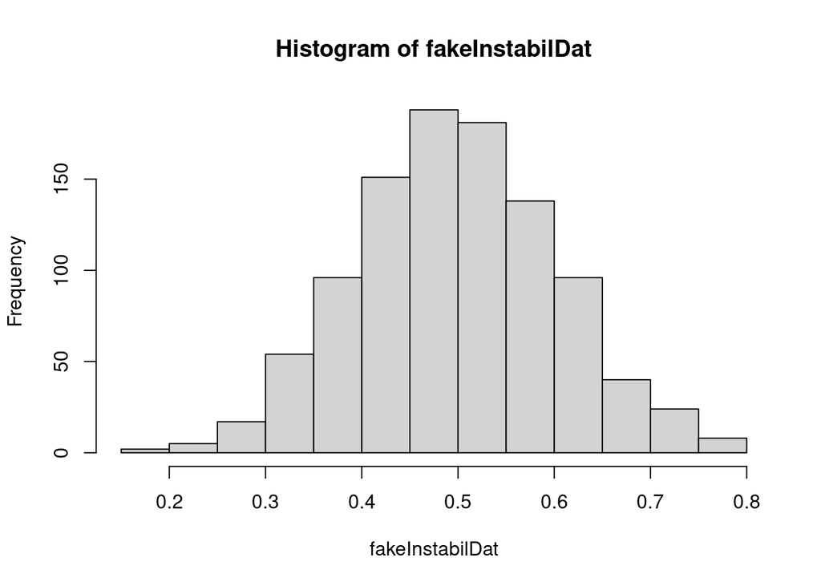

```r
fakeInstabilDat <- rnormt(1000, c(0, 1), 0.5, 0.1)

hist(fakeInstabilDat)
```

### Assuming that the distribution of instability scores is symmetrical…

Lets set our indicator of central tendency to be the mean of the above distribution – just for starters – and see about generating some Diagnostic scores.

From my conversations with Derek and Clem, I understand that we want “good code” to have higher diagnostic scores and that “bad code” (those with either a God class on one extreme or a ripple effect on the other extreme) to have lower diagnostic scores. We need these Diagnostic scores to be scaled between $(0,1)$.

We are assuming that the distribution of scores is going to be symmetrical. Derek thinks this is likely to be true, but it would be good to check with Andrew to see what his data have to say. In this example, we obviously know the distribution is symmetrical because we created it.

Below, I take the absolute value of the difference between the central tendency (expected value) and the instability scores (observed values), which has the effect of folding the distribution in half around the central tendency. The reason that we do this is that that the value wherein the majority of the instability scores (outputted from Roslynator) land is the place where we want our diagnostic scores to be maximized. Here, that value is the central tendency, and this will be true so long as the distribution in instability scores is symmetrical.

```r
# Use the mean as the measure of central tendency.
centralTend <- mean(fakeInstabilDat)

# Folded instability scores
foldedDiagScores <- abs(centralTend - fakeInstabilDat)

# Calculate the range of scores after we folded the distribution
foldedDiagScores.range <- diff(range(foldedDiagScores), 1)

# Interpolate values from scores
foldedDiagnosticVals <- 1 - foldedDiagScores/foldedDiagScores.range
```

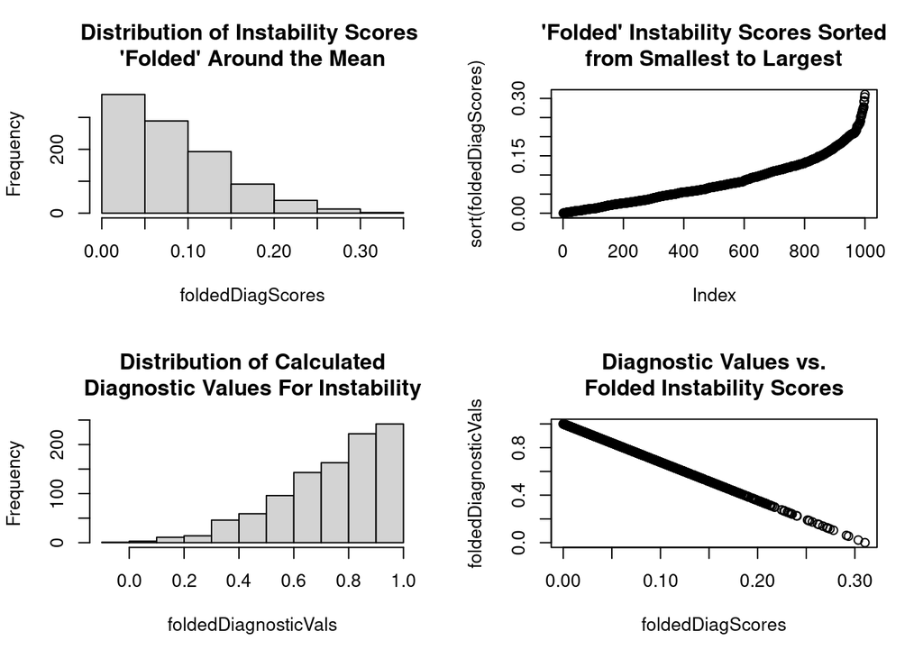

```r
# Basic plots looking at the relationships in the data

par(mfrow = c(2,2))
hist(foldedDiagScores, main = "Distribution of Instability Scores \n'Folded' Around the Mean")
plot(sort(foldedDiagScores), main = "'Folded' Instability Scores Sorted\nfrom Smallest to Largest")
hist(foldedDiagnosticVals, main = "Distribution of Calculated\nDiagnostic Values For Instability")
plot(foldedDiagnosticVals ~ foldedDiagScores, main = "Diagnostic Values vs.\nFolded Instability Scores")
```

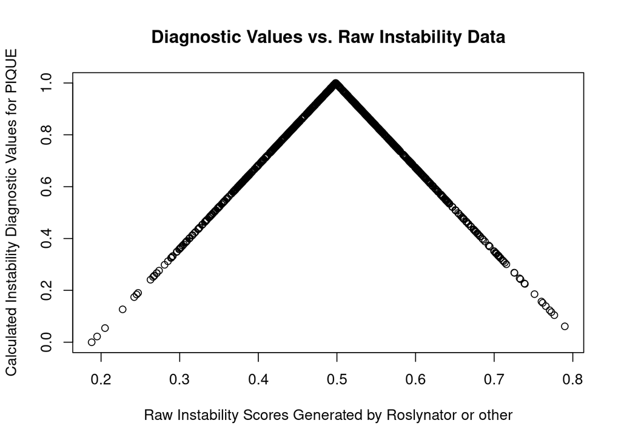

```r
par(mfrow = c(1,1))
plot(foldedDiagnosticVals ~ fakeInstabilDat, xlab = "Raw Instability Scores Generated by Roslynator or other", ylab= "Calculated Instability Diagnostic Values for PIQUE", main = "Diagnostic Values vs. Raw Instability Data")
```

## Method II: An approach for multimodal data and generally agnostic to distribution

### Simulate some bimodal data.

To keep in line with instability scores, I bound this data `[0,1]`.

This first chunk is simply a function that I wrote so that we can rescale the values in the distribution between `[0,1]`.

```r
# custom function to linearly rescale a vector of data between 2 vals; run it and store in
# the enviro
reScale <- function(obs, minOfNewScale, maxOfNewScale){
  minObs <- range(obs)[1]
  maxObs <- range(obs)[2]

  # Map measurement to [0, maxObs-minObs]
  newObs <- obs - minObs

  # Divide above by range in observation to map observations between [0, 1]
  newObs <- newObs / (maxObs - minObs)

  # Map Obs to [0, maxOfNewScale - minOfNewScale]
  newObs <- newObs * (maxOfNewScale - minOfNewScale)

  # Add minOfNewScale to shift the obs to [minOfNewScale, maxOfNewScale]
  newObs <- newObs + minOfNewScale
}
```

### Create a bimodal distribution of fake data.

I used `rbeta` to do this and varied the shape parameters for the two different distributions that we will link together. The purpose of this is so that the two distributions look different from one another, as they often do in “real” data.

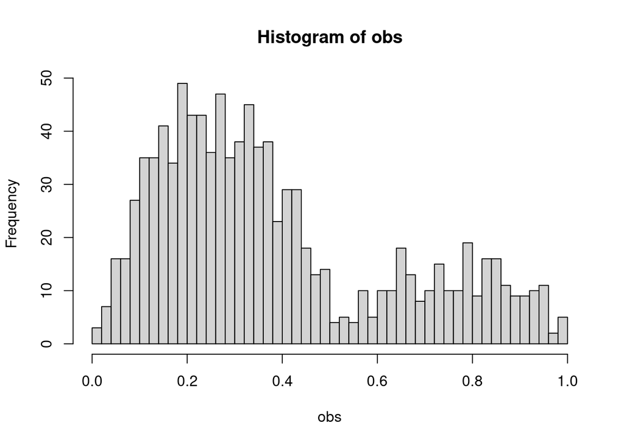

```r
# create a test data set that is bimodal...start by creating 2 distributions b/w
# [0,1]; use beta distribution b/c its easy
obs1 <- rbeta(750, 2, 2)
obs2 <- rbeta(250, 1.75, 1.75)

# rescale them
rsObs1 <- reScale(obs1, 0, 0.5)
rsObs2 <- reScale(obs2, 0.5, 1)

# join them together so that we have one bimodal distribution with values
# between [0,1]; these are data that would be what we get from Andrew
obs <- c(rsObs1, rsObs2)

# plot our new fake data representing instability scores from several programs;
# generate a frequency distribution of those data
myHist <- hist(obs, breaks = seq(0, 1, 0.02))
```

```r
# calculate the densities of the data; I did this simply using the densities
# calculated by the hist function; could do this with other R packages if we
# want/need
densities <- diff( range(myHist$breaks), 1)/length(myHist$counts) * myHist$density

# check that the area is 1
if( sum(densities) < 0.999 || sum(densities) > 1.001 ) {
stop("Failed to rescale correctly. Sum of densities should equal 1.")
}

# now we have to twist our heads a bit linearize the densities between
# [0,1]...where density is high, we want a bigger Diagnostic Value
instabilityDiagnosticValues <- reScale(densities, 0, 1)
instabilityScores <- myHist$mids
```

### Exploring the utility of GAMs

For this analysis, I used the `mgcv` package. R also has a package called `gam` which obviously also is used for this purpose. There are some differences in how these packages operate, but the results are generally similar.

```r
# load the library that runs generalized additive models
library(mgcv)
# run the model with smoothed instability scores as our independent variable
mod <- gam(instabilityDiagnosticValues ~ s(instabilityScores))
summary(mod)
```

```
##
## Family: gaussian
## Link function: identity
##
## Formula:
## instabilityDiagnosticValues ~ s(instabilityScores)
##
## Parametric coefficients:
##             Estimate Std. Error t value Pr(>|t|)
## (Intercept)  0.38298    0.01245   30.75   <2e-16 ***
## ---
## Signif. codes:  0 '***' 0.001 '**' 0.01 '*' 0.05 '.' 0.1 ' ' 1
##
## Approximate significance of smooth terms:
##                        edf Ref.df     F p-value
## s(instabilityScores) 7.628  8.526 59.72  <2e-16 ***
## ---
## Signif. codes:  0 '***' 0.001 '**' 0.01 '*' 0.05 '.' 0.1 ' ' 1
##
## R-sq.(adj) =  0.912   Deviance explained = 92.6%
## GCV = 0.0093725  Scale est. = 0.0077551  n = 50
```

Below, we have a look at our model fits and predictions (left panel) for the distrubution of scores depicted in the histogram (right panel). Left panel: Model fit (black line) and predicted values for a suite of instability scores (red points). Right panel: Histogram of instability scores.

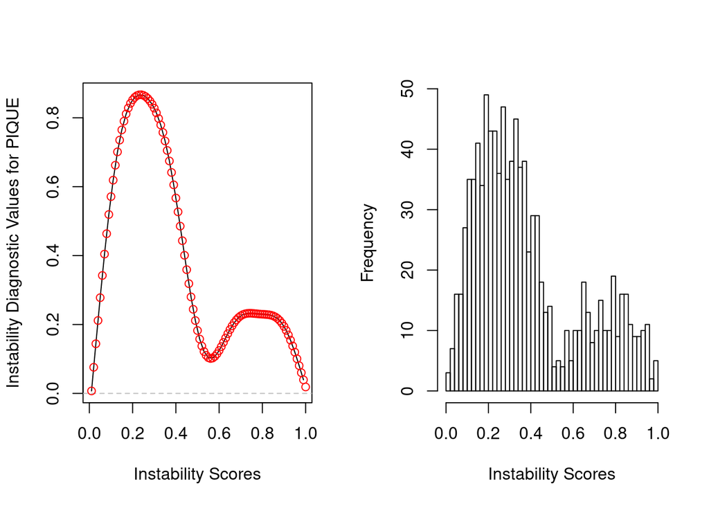

```r
par(mfrow = c(1,2))

# have a look at the results of our benchmark model
plot(
  instabilityScores, fitted(mod),
  type = "l",
  ylab = "Instability Diagnostic Values for PIQUE",
  xlab = "Instability Scores"
  )
abline(h = 0, col = "grey", lty = 2)

# make up some new data to map to our benchmark model
newScores <- seq(0, 1, 0.01)

# use the GAM to predict what the new Vals for PIQUE should be (these should
# plot directly atop the line with the model fit)
newVals <- predict(mod, newdata = list(instabilityScores = newScores))
newPoints <- Map(c, newScores, newVals)
invisible(
  lapply(newPoints, function(p) points(p[1], p[2], col = "red"))
)

# plot the histogram next to this to see how the Diaganostic Values relate to
# the frequency distribution
plot(myHist, xlab = "Instability Scores", main = "")
```